# COMPSCIX 415.2 Homework 2

Claude Phan

2/10/19

My Github repository for my assignments can be found at this URL: https://github.com/claudephan/compscix-415-2-assignments.git

```r
library(mdsr)
library(tidyverse)
library(ggplot2)
```

## Exercise 3.2.4

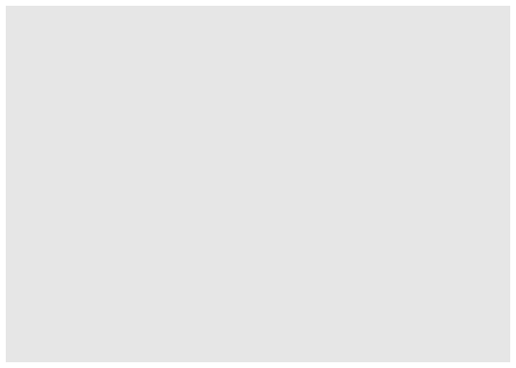

```r
ggplot(data = mpg)
```

1. Running ggplot(data = mpg) shows a pot with nothing in it as we did not define what to plot or any aes

```r
glimpse (mpg)
```

```
## Observations: 234
## Variables: 11
## $ manufacturer <chr> "audi", "audi", "audi", "audi", "audi", "audi", "au…
## $ model        <chr> "a4", "a4", "a4", "a4", "a4", "a4", "a4", "a4 quatt…
## $ displ        <dbl> 1.8, 1.8, 2.0, 2.0, 2.8, 2.8, 3.1, 1.8, 1.8, 2.0, 2…
## $ year         <int> 1999, 1999, 2008, 2008, 1999, 1999, 2008, 1999, 199…
## $ cyl          <int> 4, 4, 4, 4, 6, 6, 6, 4, 4, 4, 4, 6, 6, 6, 6, 6, 6, …
## $ trans        <chr> "auto(l5)", "manual(m5)", "manual(m6)", "auto(av)",…
## $ drv          <chr> "f", "f", "f", "f", "f", "f", "f", "4", "4", "4", "…
## $ cty          <int> 18, 21, 20, 21, 16, 18, 18, 18, 16, 20, 19, 15, 17,…
## $ hwy          <int> 29, 29, 31, 30, 26, 26, 27, 26, 25, 28, 27, 25, 25,…
## $ fl           <chr> "p", "p", "p", "p", "p", "p", "p", "p", "p", "p", "…
## $ class        <chr> "compact", "compact", "compact", "compact", "compac…
```

2. There are 234 rows in mpg.

```r
?mpg
```

3. drv variable describes the wheel drive type of the car. f = front-wheel drive, r = rear wheel drive, 4 = 4wd

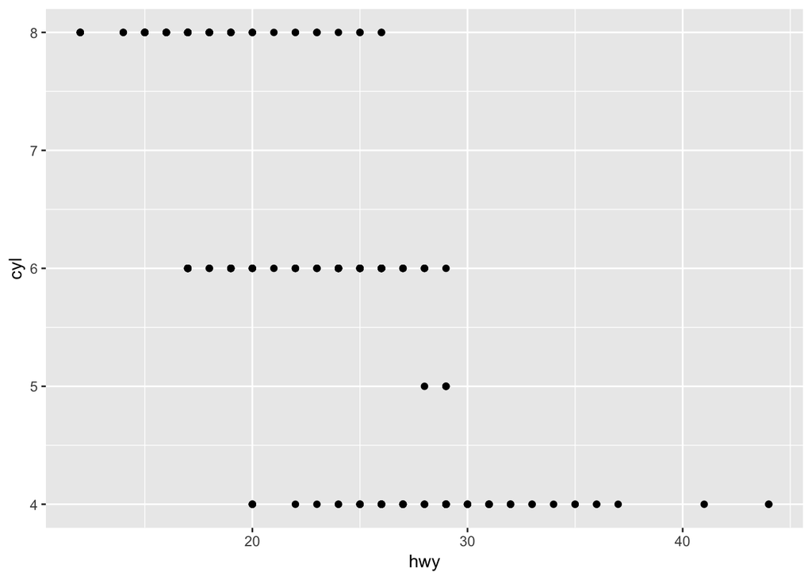

```r
ggplot(data = mpg) +
  geom_point(mapping = aes(x = hwy, y = cyl))
```

4. The scatter plot above is of hwy vs cyl

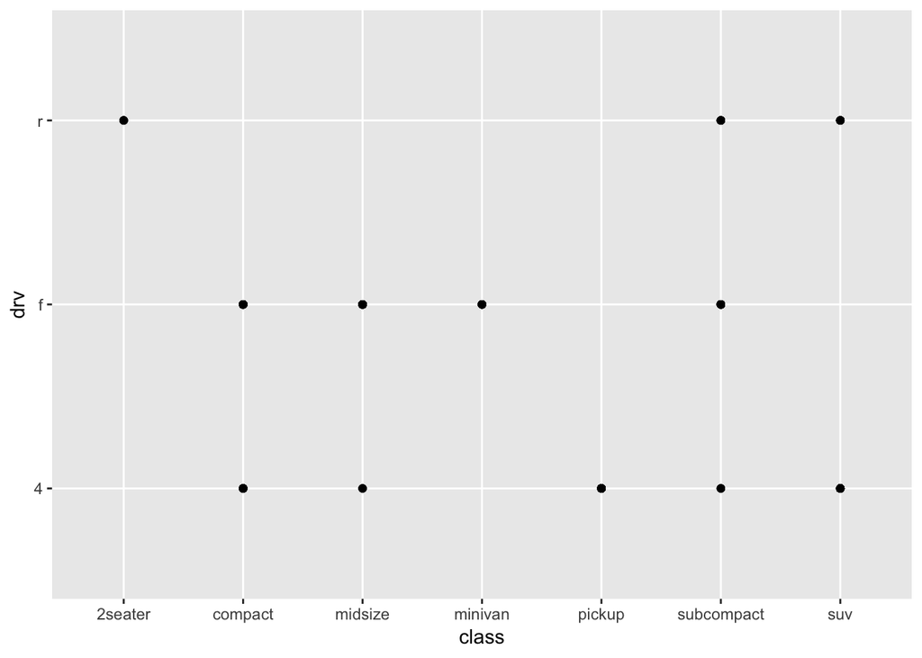

```r
ggplot(data = mpg) +
  geom_point(mapping = aes(x = class, y = drv))
```

5. The scatter plot of class vs drv is not very useful as class is a categorical variable. We are not even able to see how many of each drv type belong to each class.

## Exercise 3.3.1

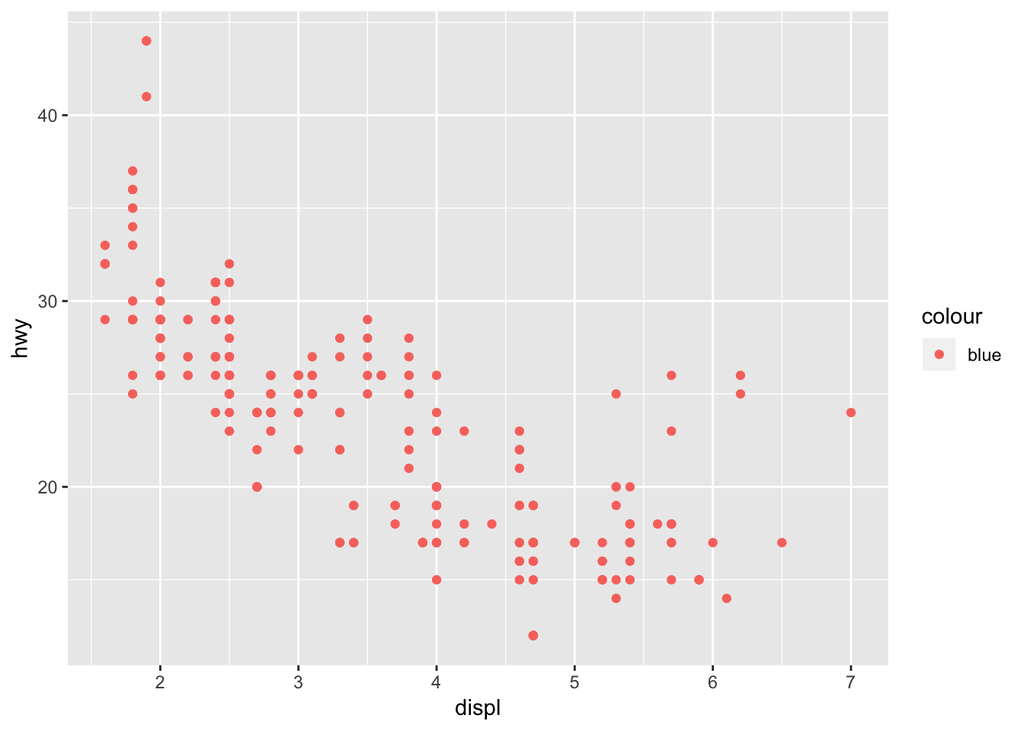

```r
ggplot(data = mpg) +
  geom_point(mapping = aes(x = displ, y = hwy, color = "blue"))
```

1. The color doesn’t convey information about the variable, therefor to set an aesthetic manually, we set have to set it as an argument of the geom function, aka outside of aes()

```r
summary(mpg)
```

```
##  manufacturer          model               displ            year
##  Length:234         Length:234         Min.   :1.600   Min.   :1999
##  Class :character   Class :character   1st Qu.:2.400   1st Qu.:1999
##  Mode  :character   Mode  :character   Median :3.300   Median :2004
##                                        Mean   :3.472   Mean   :2004
##                                        3rd Qu.:4.600   3rd Qu.:2008
##                                        Max.   :7.000   Max.   :2008
##       cyl           trans               drv                 cty
##  Min.   :4.000   Length:234         Length:234         Min.   : 9.00
##  1st Qu.:4.000   Class :character   Class :character   1st Qu.:14.00
##  Median :6.000   Mode  :character   Mode  :character   Median :17.00
##  Mean   :5.889                                         Mean   :16.86
##  3rd Qu.:8.000                                         3rd Qu.:19.00
##  Max.   :8.000                                         Max.   :35.00
##       hwy             fl               class
##  Min.   :12.00   Length:234         Length:234
##  1st Qu.:18.00   Class :character   Class :character
##  Median :24.00   Mode  :character   Mode  :character
##  Mean   :23.44
##  3rd Qu.:27.00
##  Max.   :44.00
```

2. categorical: manufacturer, model, trans, drv, fl, class continuous: displ, year, cyl, cty, hwy We can see this information when we run mph by using Summary on mpg

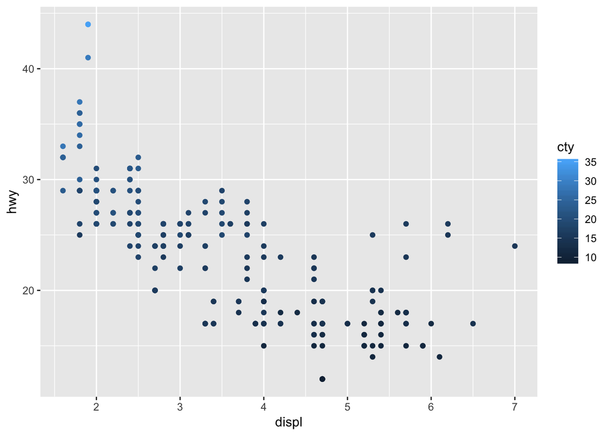

```r
ggplot(data = mpg) +
  geom_point(mapping = aes(x = displ, y = hwy, color = cty))
```

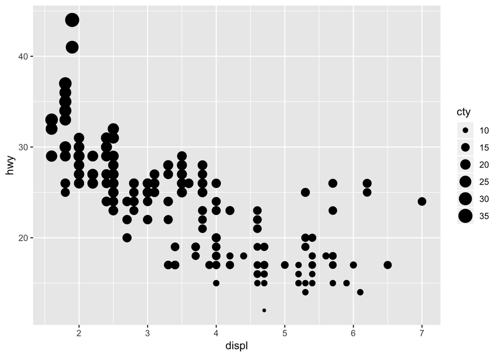

```r
ggplot(data = mpg) +
  geom_point(mapping = aes(x = displ, y = hwy, size = cty))
```

```r
#ggplot(data = mpg) +
#  geom_point(mapping = aes(x = displ, y = hwy, shape = cty))
```

3. For color, different hues of the color represented the different variation in cty MPG. For shape, larger circles represented higher amounts of cty MPG vs smaller circles for lower cty MPG. However, shape was not able to be mapped, because there are a finite number of unique shapes, that wouldn’t be able to map all the different values a contentious variable can take.

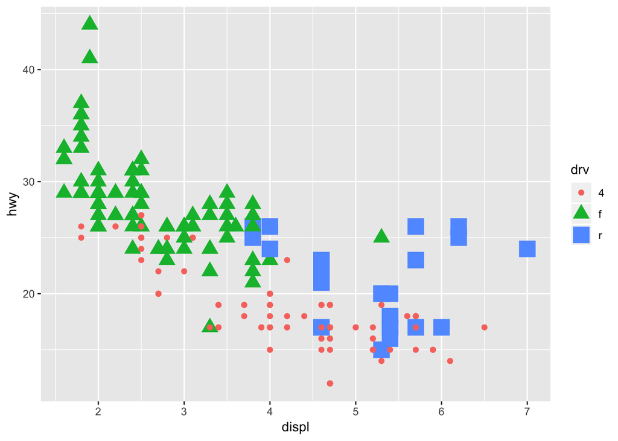

```r
ggplot(data = mpg) +
  geom_point(mapping = aes(x = displ, y = hwy, size = drv, color = drv, shape = drv))
```

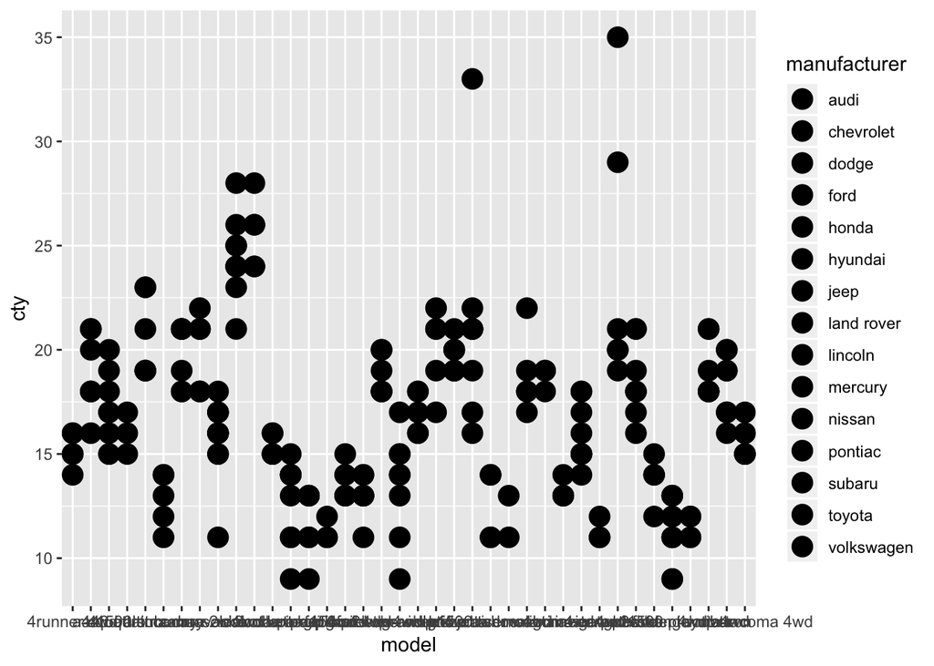

```r
ggplot(mpg, aes(model, cty, fill = manufacturer)) +
  geom_point(stroke = 3)
```

5. The stroke aesthetic is used to modify the width of the border of shapes that have them. This works with shape 21.

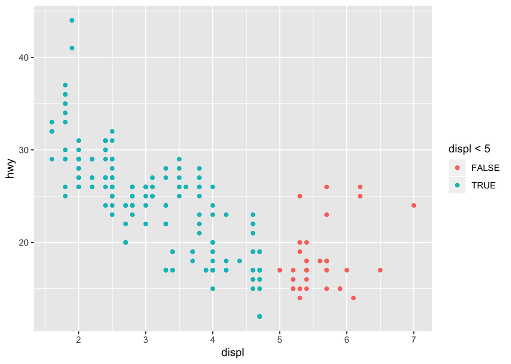

```r
ggplot(data = mpg) +
  geom_point(mapping = aes(x = displ, y = hwy, color = displ < 5))
```

6. When you map an aesthetics to something other than a a variable name, such as a conditional statement, it evaluates each point against that statement and sets them accordingly. In the example above, all values of displ less than 5 were evaluated as True and colored teal, while at least 5 were with red.

## Exercise 3.5.1

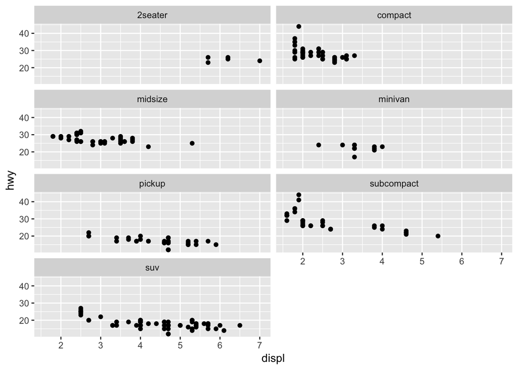

```r
ggplot(data = mpg) +
  geom_point(mapping = aes(x = displ, y = hwy)) +
  facet_wrap(~ class, ncol = 2)
```

4. Using faceting vs color allows for another degree of separation. This makes the relationships for each class vs the x & y a lot easier to see as they each have their own mini plot. The disadvantage here is that it is more difficult to see how all this data relates to one another, especially for plots with similar patterns such as compact and subcompact. If there were in the same plot, just colored different, the relationship would be a bit more obvious. For very larger data sets, it would probably be better to use faceting as having too many plots of different colors all on one plot would be too much clutter to process.

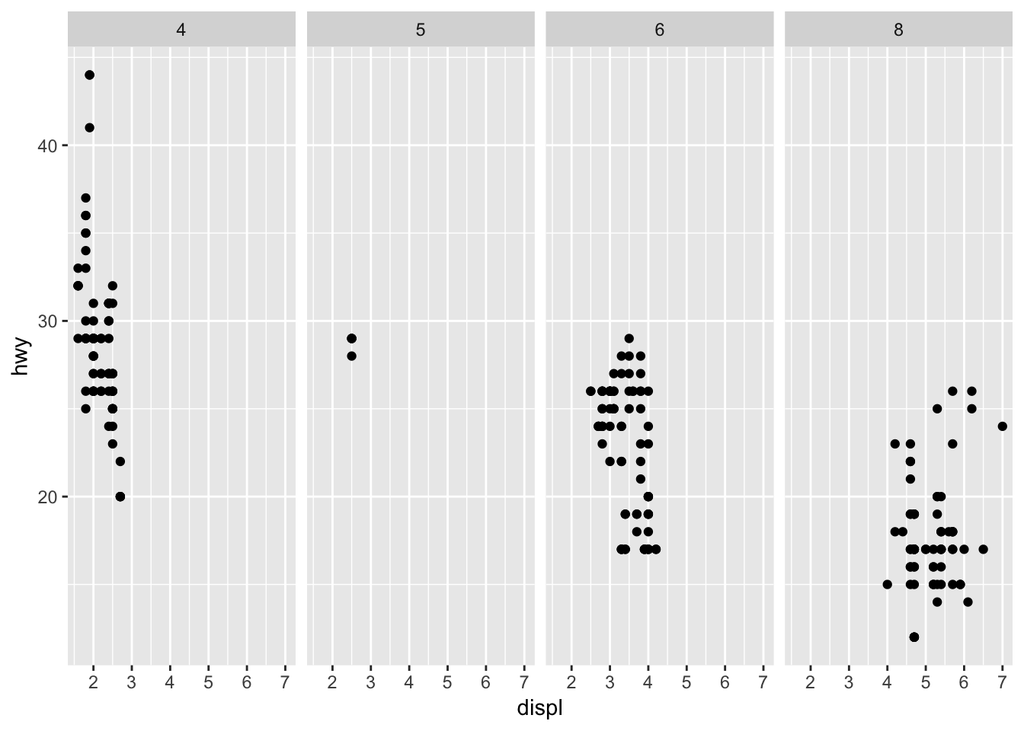

```r
ggplot(data = mpg) +
  geom_point(mapping = aes(x = displ, y = hwy)) +
  facet_grid(. ~ cyl)
```

5. Facet_wrap allows you to control the output display of the plots using ncols and nrows. They stand for number of columns and number of rows and control only the display output. Facet_grid doesn’t have ncols or nrows because the number of columns and rows is determined by the variables passed into the facet_grid argument.

## Section 3.6.1

1. What geom would you use to draw a line chart? A boxplot? A histogram? An area chart?

   line chart : geom_line boxplot : geom_boxplot histogram : geom_histogram area chart : geom_area

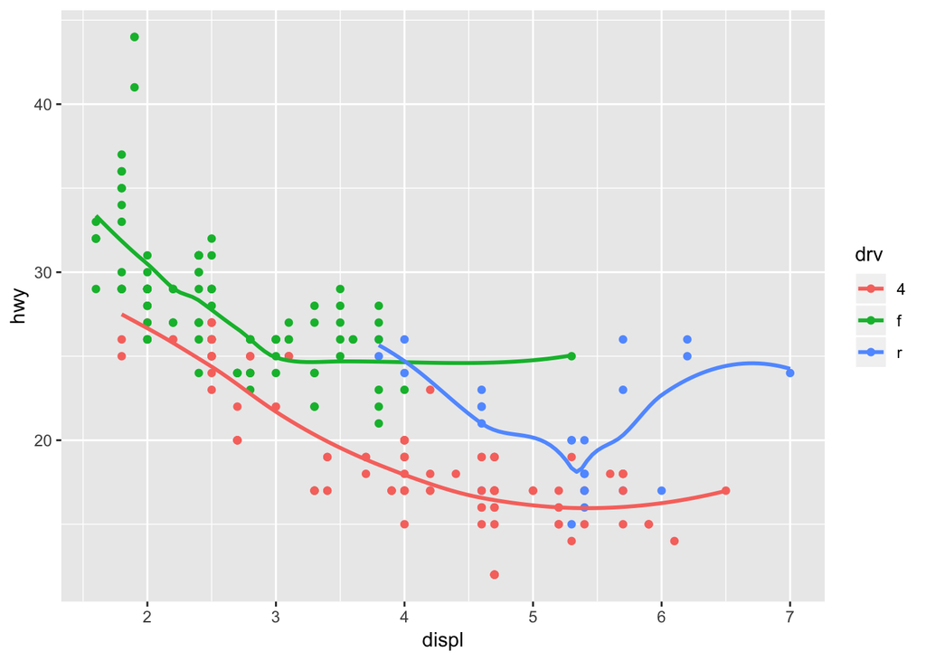

```r
ggplot(data = mpg, mapping = aes(x = displ, y = hwy, color = drv)) +
  geom_point() +
  geom_smooth(se = FALSE)
```

2. The above code is predicted to be a plot of displ vs hwy. Along with color coordination for drv. The plot will be a dot plot with a trend curve overlay on it.

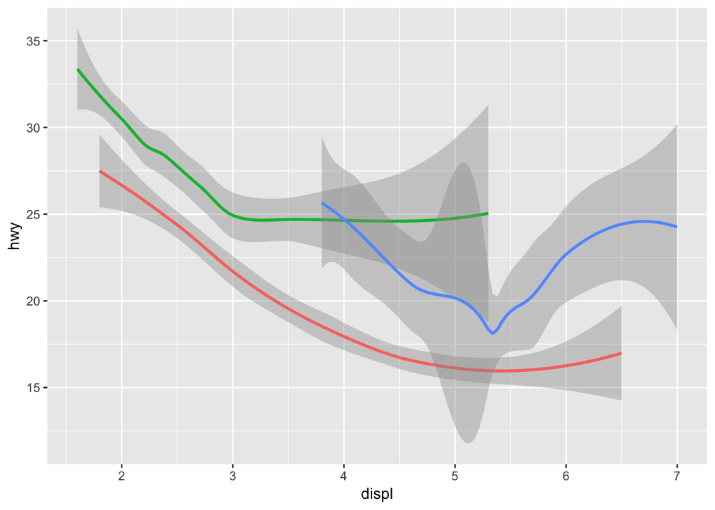

```r
ggplot(data = mpg) +
  geom_smooth(
    mapping = aes(x = displ, y = hwy, color = drv),
    show.legend = FALSE
  )
```

3. show.legend = False controls if the plot’s legend will show or not. If we remove remove it or set it to True, we’ll see the legend. I think it was used earlier in the chapter because multiple graphs were being compared to one another, in a situation like that, it is unnecessary to have multiple legends.
4. The se agrument in geom_smooth is for displaying a confidence interval around the smooth line.

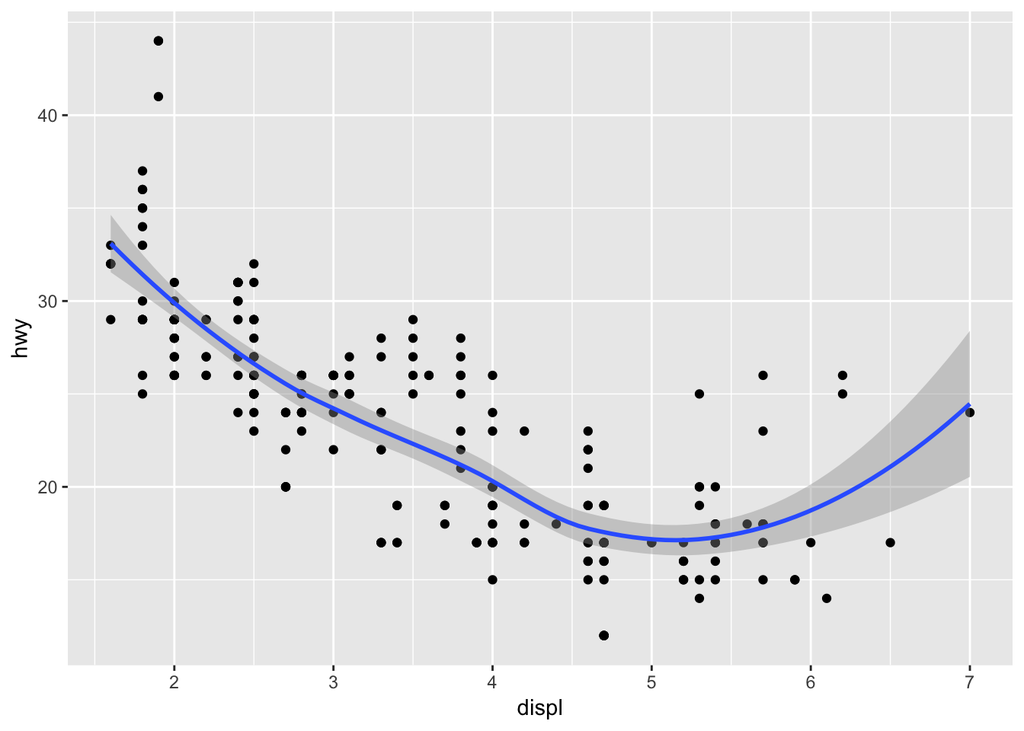

```r
ggplot(data = mpg, mapping = aes(x = displ, y = hwy)) +
  geom_point() +
  geom_smooth()
```

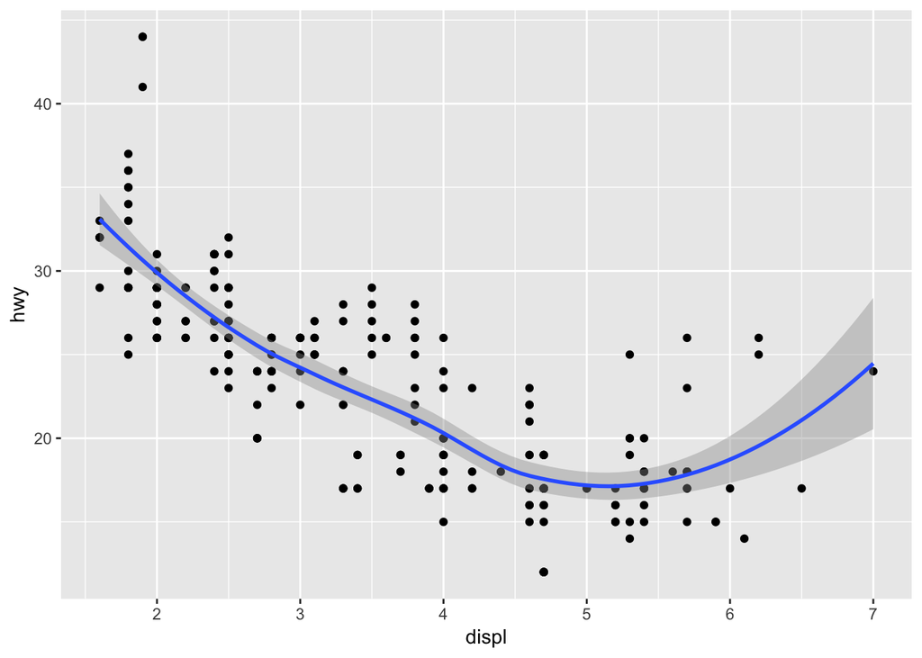

```r
ggplot() +
  geom_point(data = mpg, mapping = aes(x = displ, y = hwy)) +
  geom_smooth(data = mpg, mapping = aes(x = displ, y = hwy))
```

5. Will these two graphs look different? Why/why not?

No they are essentially the same thing. ggplot is essentiallys visul layers on top of the plot. Since the aes mapping is the samne for geom_point and geom_smooth, you only need to write the mapping once, and it can be done in the plot definition.

6. Recreate the R code necessary to generate the following graphs.

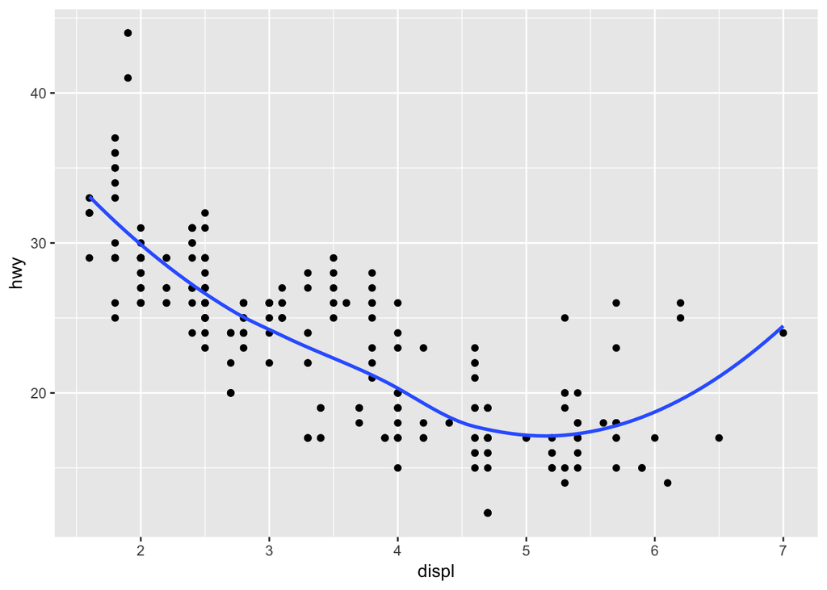

```r
ggplot(data = mpg, mapping = aes(x = displ, y = hwy)) +
  geom_point() +
  geom_smooth(se = FALSE)
```

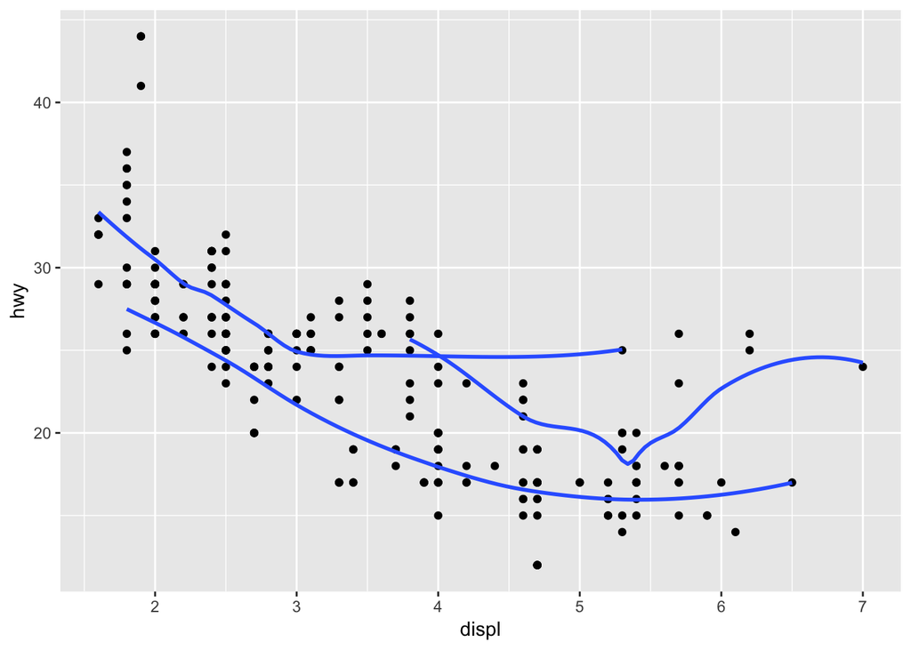

```r
ggplot(data = mpg, mapping = aes(x = displ, y = hwy)) +
  geom_point() +
  geom_smooth(mapping = aes(x = displ, y = hwy, group = drv), se = FALSE)
```

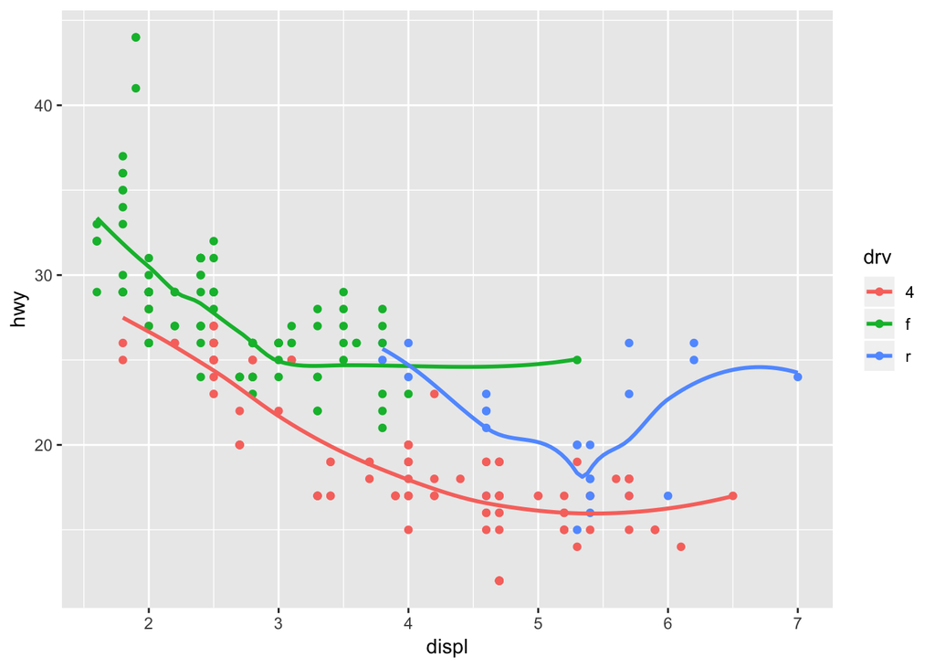

```r
ggplot(data = mpg, mapping = aes(x = displ, y = hwy, color = drv)) +
  geom_point() +
  geom_smooth(mapping = aes(x = displ, y = hwy, group = drv), se = FALSE)
```

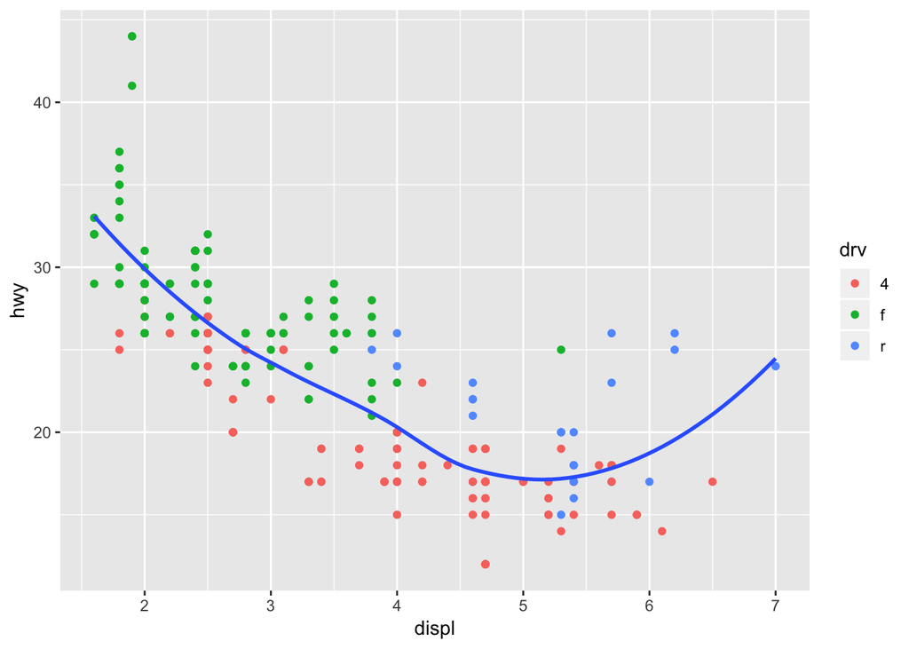

```r
ggplot(data = mpg, mapping = aes(x = displ, y = hwy)) +
  geom_point(mapping = aes(x = displ, y = hwy, color = drv)) +
  geom_smooth(se = FALSE)
```

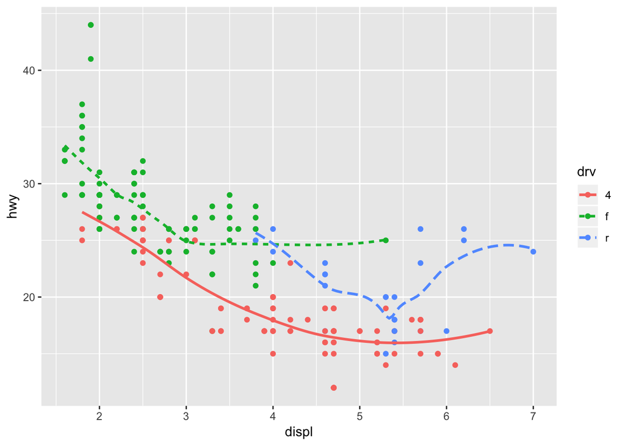

```r
ggplot(data = mpg, mapping = aes(x = displ, y = hwy, color = drv)) +
  geom_point() +
  geom_smooth(mapping = aes(x = displ, y = hwy, linetype = drv), se = FALSE)
```

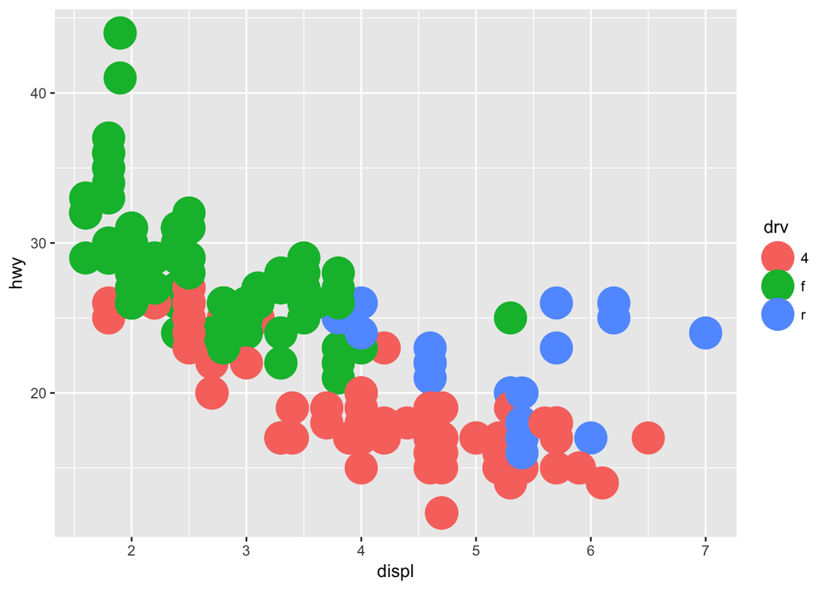

```r
ggplot(data = mpg, mapping = aes(x = displ, y = hwy, color = drv)) +
  geom_point(pch = 19, stroke = 6)
```

## Section 3.7.1

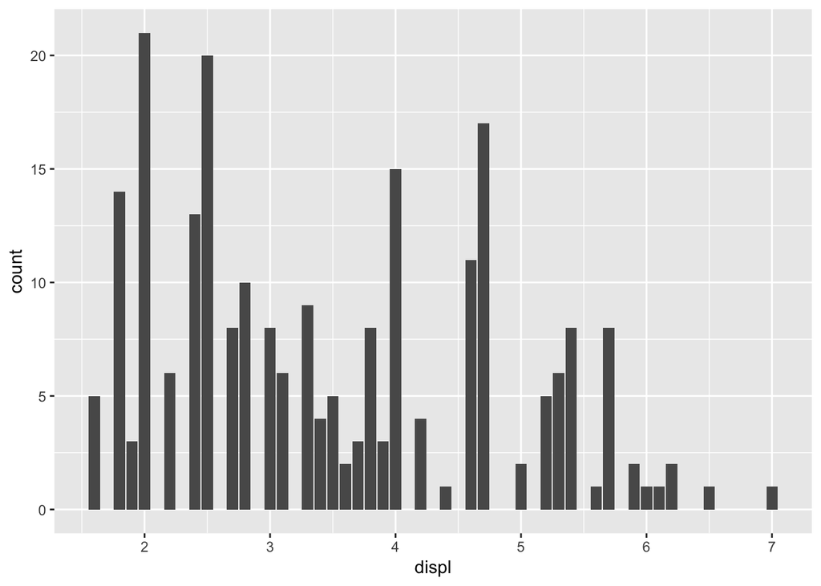

```r
ggplot(data = mpg, mapping = aes(x = displ)) +
  geom_bar()
```

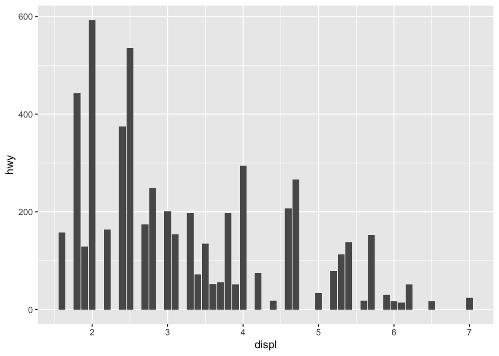

```r
ggplot(data = mpg, mapping = aes(x = displ, y = hwy)) +
  geom_col()
```

2. Geom_bar takes in an x variabler and makes the heights of the bars equal to the counts. Geom_col takes in both an x & y, thus the heights of the bars represent values of the y variable.

Answer these questions: 1. Look at the data graphics at the following link: What is a Data Scientist. Please briefly critique the designer’s choices. What works? What doesn’t work? What would you have done differently?

The color schedule is really depressing. Not very happy to read through. I really throught the descrption of Big data science vs normal data science was funny. I don’t think a scenario that fits “normal” data science ever occurs.